# troubleshoot x-l crabs

M Fisher

2023-09-27

```
## ------------------------------
## NRG/setup.R settings
## ------------------------------
## ------------------------------
## ------------------------------
```

## Test sim

For now, use temperature loggers from the intertidal in Willapa Bay, WA. Provided by WSG Crab Team

starting and ending weight observations

```r
W_start <- 0.004518174
W_end <-  1.494803
```

for now, make the crab a cannibal

```r
dcrab_data$Eprey <- dcrab_data$Epred
```

here are the parameter values

```r
parms <- crabPARMS_USE[1,]
parms
```

```
##           X RFR   Qox  a Ceq Req Weq  Tco  Tcm QC  Tcl  CK1  CK4  CA     CB
## 1 Cmagister   1 13560 NA   3   0   1 14.5 20.2  5 21.2 0.42 0.83 6.6 -0.256
##      RA     RB QR Tro Trm  SA Am   FA   UA    ED Bact RK4 Trl RK1
## 1 0.012 -0.029 NA  NA  NA 0.2  1 0.65 0.04 19380   NA  NA  NA  NA
##                               Notes
## 1 Energy measured as: J / gAFDW / d
```

```r
sim_dat <- dcrab_data
sim_dat$propDiet <- 1

## temperatures
sim_dat$TempC <- summerTdat$TempC     ## temperatures

## starting crab weight
sim_dat$W     <- W_start         ## set W data for the simulation to the first observed weight


##
nd     <-  dim(summerTdat)[1] # days of simulation

## weights at start and end of simulation
Wobs   <- data.frame(
  day = c(1,nd),
  W   = c(W_start,W_end))
Wobs$date <- summerTdat$date[Wobs$day]

# simulation data frames
DCRBdat4sim   <- list(
                  Wtarget  = Wobs,
                  parSIM  = parms,
                  simTdat = summerTdat,
                  dataSIM  = sim_dat,
                  dataMOLT = dataMOLT$Cmagister)

sim_out       <- summerTdat %>% mutate(W=0)
```

simulate!

```r
test.sim <- sim_W(par=parms$RFR, dataIN=DCRBdat4sim, LL=F)
```

```
## WARNING: crab weight is less than 8% of carapace width on day 2. (2.122%)
```

```
## daily growth includes energy lost to exuvia / spawning (3235.99 J/g predator)
```

```
## carapace width 403.57 calculated from weight; using the equation: 0.000164 * CW^2.79.
```

```
## daily growth includes energy lost to exuvia / spawning (3235.99 J/g predator)
```

```
## carapace width 1175.5 calculated from weight; using the equation: 0.000164 * CW^2.79.
```

```
## daily growth includes energy lost to exuvia / spawning (3235.99 J/g predator)
```

```
## carapace width 2003.18 calculated from weight; using the equation: 0.000164 * CW^2.79.
```

```
## daily growth includes energy lost to exuvia / spawning (3235.99 J/g predator)
```

```
## carapace width 3236.29 calculated from weight; using the equation: 0.000164 * CW^2.79.
```

```
## daily growth includes energy lost to exuvia / spawning (3235.99 J/g predator)
```

```
## carapace width 4305.93 calculated from weight; using the equation: 0.000164 * CW^2.79.
```

```
## Your crab molted on day: 18, 36, 54, 74, 91,
```

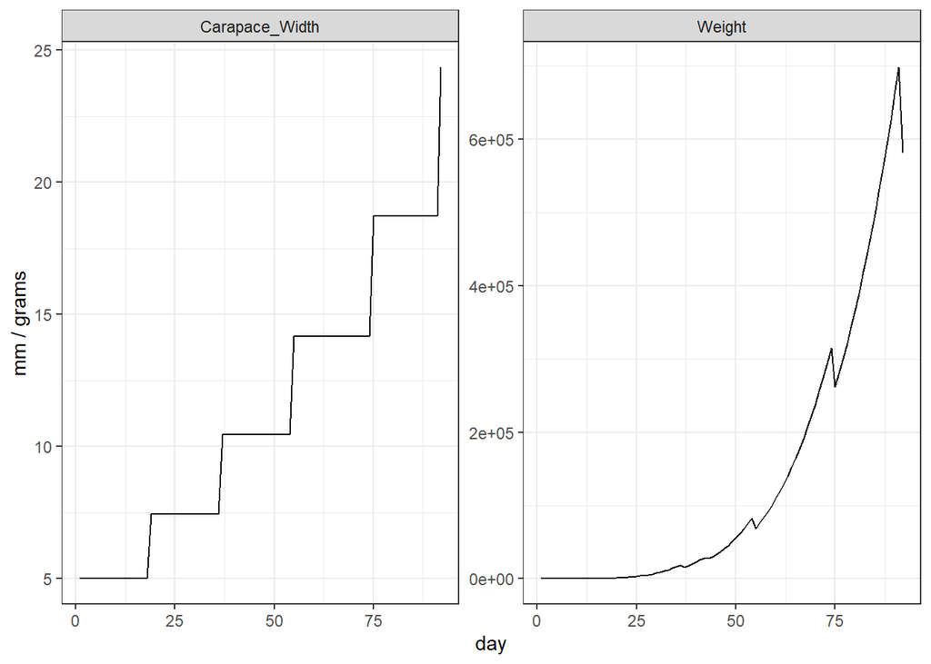

Weight is… large.

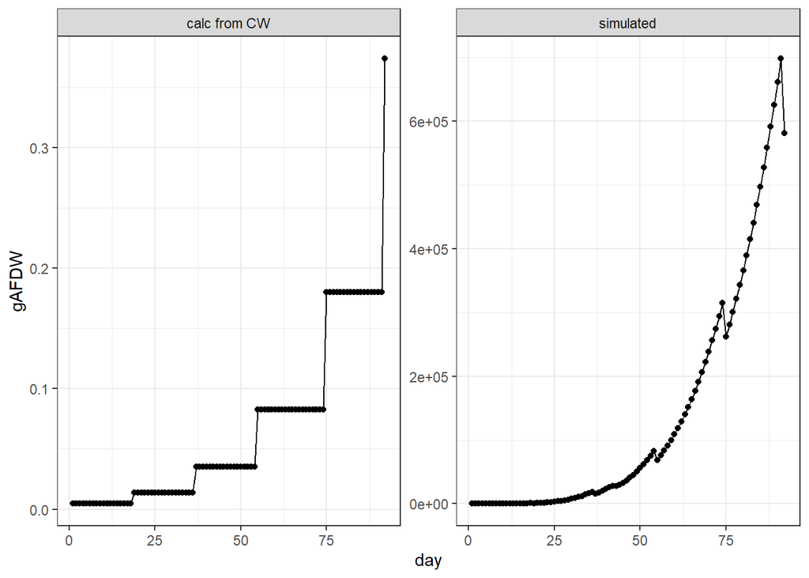

```r
data.frame(day=rep(1:(nd+1), 2),
           type=c(rep("simulated",nd+1),rep("calc from CW",nd+1)),
           gAFDW=c(test.sim$W,sapply(test.sim$CW,cw2afdw))) %>%
  ggplot(aes(x=day,y=gAFDW)) +
  geom_point() + geom_path() +
  facet_wrap(~type, scales="free_y") + labs("RFR=1; pIloss=0; pIndigest=0")
```

### RFR to 0.75

```r
test.sim2 <- sim_W(par=0.75, dataIN=DCRBdat4sim, LL=F)
```

```
## WARNING: crab weight is less than 8% of carapace width on day 2. (1.141%)
```

```
## WARNING: crab weight is less than 8% of carapace width on day 3. (3.809%)
```

```
## daily growth includes energy lost to exuvia / spawning (3235.99 J/g predator)
```

```
## carapace width 274.95 calculated from weight; using the equation: 0.000164 * CW^2.79.
```

```
## daily growth includes energy lost to exuvia / spawning (3235.99 J/g predator)
```

```
## carapace width 791.07 calculated from weight; using the equation: 0.000164 * CW^2.79.
```

```
## daily growth includes energy lost to exuvia / spawning (3235.99 J/g predator)
```

```
## carapace width 1343.97 calculated from weight; using the equation: 0.000164 * CW^2.79.
```

```
## daily growth includes energy lost to exuvia / spawning (3235.99 J/g predator)
```

```
## carapace width 2168 calculated from weight; using the equation: 0.000164 * CW^2.79.
```

```
## daily growth includes energy lost to exuvia / spawning (3235.99 J/g predator)
```

```
## carapace width 2882.61 calculated from weight; using the equation: 0.000164 * CW^2.79.
```

```
## Your crab molted on day: 18, 36, 54, 74, 91,
```

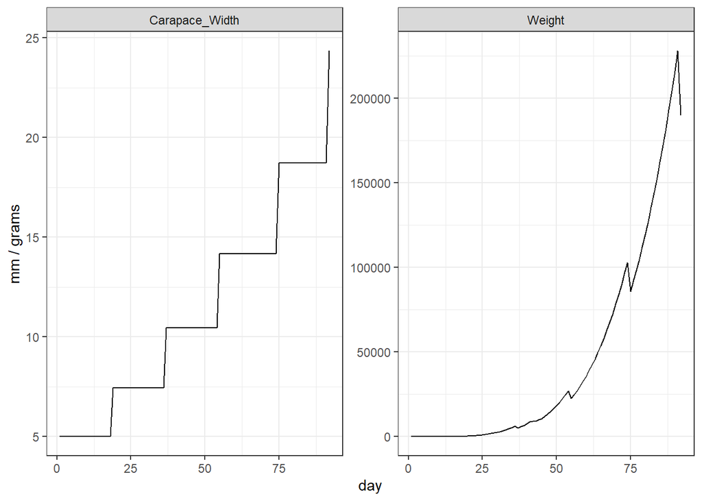

```r
plot.sim(sim.out =test.sim2,nd=nd)
```

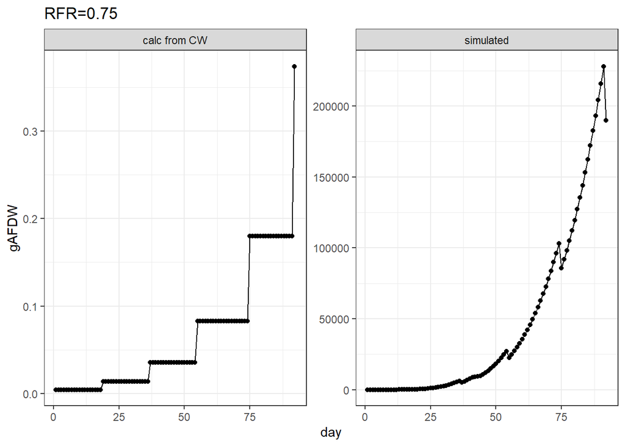

```r
data.frame(day=rep(1:(nd+1), 2),
           type=c(rep("simulated",nd+1),rep("calc from CW",nd+1)),
           gAFDW=c(test.sim2$W,sapply(test.sim2$CW,cw2afdw))) %>%
  ggplot(aes(x=day,y=gAFDW)) +
  geom_point() + geom_path() +
  facet_wrap(~type, scales="free_y") + labs(title="RFR=0.75")
```

### RFR to 0.75, I loss > 0

I found some graphs from Sean that make it look like Ingestion loss for Dungeness crab may vary across temperatures, but it mostly seems to be < 0.10

```r
sim_dat <- dcrab_data
sim_dat$propDiet <- 1
sim_dat$propIloss <- 0.10
```

```r
## temperatures
sim_dat$TempC <- summerTdat$TempC     ## temperatures

## starting crab weight
sim_dat$W     <- W_start         ## set W data for the simulation to the first observed weight


##
nd     <-  dim(summerTdat)[1] # days of simulation

## weights at start and end of simulation
Wobs   <- data.frame(
  day = c(1,nd),
  W   = c(W_start,W_end))
Wobs$date <- summerTdat$date[Wobs$day]

# simulation data frames
DCRBdat4sim   <- list(
                  Wtarget  = Wobs,
                  parSIM  = parms,
                  simTdat = summerTdat,
                  dataSIM  = sim_dat,
                  dataMOLT = dataMOLT$Cmagister)

sim_out       <- summerTdat %>% mutate(W=0)
```

```r
test.sim3 <- sim_W(par=0.75, dataIN=DCRBdat4sim, LL=F)
```

```
## WARNING: crab weight is less than 8% of carapace width on day 2. (0.891%)
```

```
## WARNING: crab weight is less than 8% of carapace width on day 3. (2.826%)
```

```
## WARNING: crab weight is less than 8% of carapace width on day 4. (7.919%)
```

```
## daily growth includes energy lost to exuvia / spawning (3235.99 J/g predator)
```

```
## carapace width 238.15 calculated from weight; using the equation: 0.000164 * CW^2.79.
```

```
## daily growth includes energy lost to exuvia / spawning (3235.99 J/g predator)
```

```
## carapace width 682.95 calculated from weight; using the equation: 0.000164 * CW^2.79.
```

```
## daily growth includes energy lost to exuvia / spawning (3235.99 J/g predator)
```

```
## carapace width 1159.54 calculated from weight; using the equation: 0.000164 * CW^2.79.
```

```
## daily growth includes energy lost to exuvia / spawning (3235.99 J/g predator)
```

```
## carapace width 1870.18 calculated from weight; using the equation: 0.000164 * CW^2.79.
```

```
## daily growth includes energy lost to exuvia / spawning (3235.99 J/g predator)
```

```
## carapace width 2486.5 calculated from weight; using the equation: 0.000164 * CW^2.79.
```

```
## Your crab molted on day: 18, 36, 54, 74, 91,
```

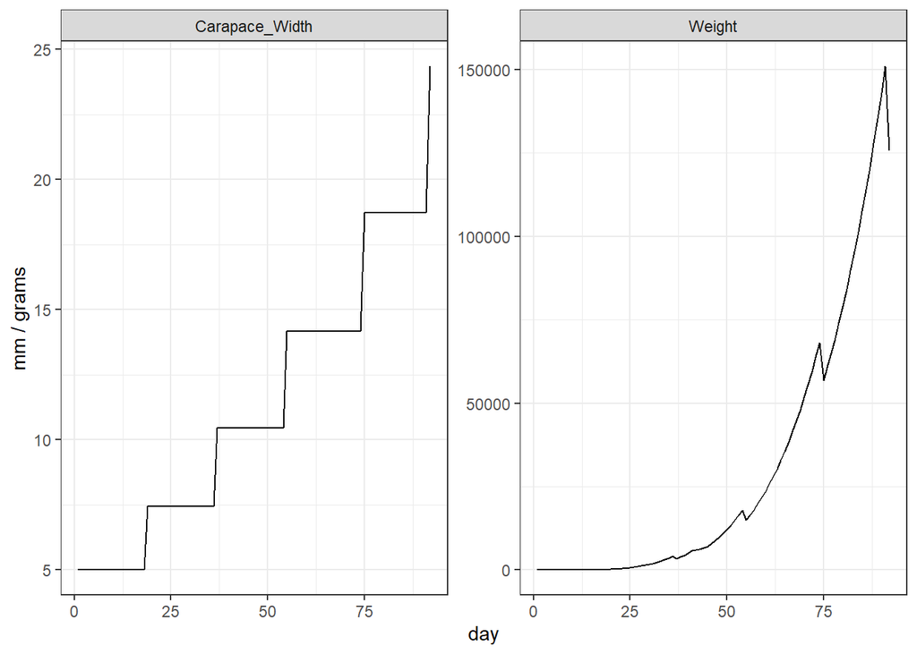

```r
plot.sim(sim.out =test.sim3,nd=nd)
```

compare simulated weight to weight based on carapace width:

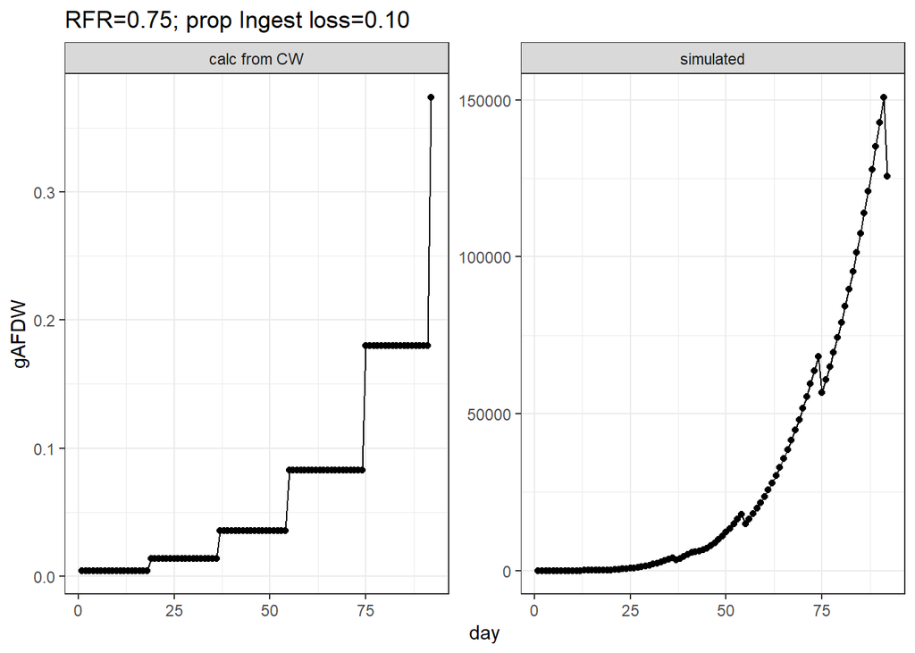

```r
data.frame(day=rep(1:(nd+1), 2),
           type=c(rep("simulated",nd+1),rep("calc from CW",nd+1)),
           gAFDW=c(test.sim3$W,sapply(test.sim3$CW,cw2afdw))) %>%
  ggplot(aes(x=day,y=gAFDW)) +
  geom_point() + geom_path() +
  facet_wrap(~type, scales="free_y") + labs(title="RFR=0.75; prop Ingest loss=0.10")
```

### RFR to 0.4, I loss > 0, Indigest > 0

Just making up indigestable biomass of consumed prey as 0.40

```r
sim_dat <- dcrab_data
sim_dat$propDiet <- 1
sim_dat$propIloss <- 0.10
sim_dat$propIndigest <- 0.40
```

```r
## temperatures
sim_dat$TempC <- summerTdat$TempC     ## temperatures

## starting crab weight
sim_dat$W     <- W_start         ## set W data for the simulation to the first observed weight


##
nd     <-  dim(summerTdat)[1] # days of simulation

## weights at start and end of simulation
Wobs   <- data.frame(
  day = c(1,nd),
  W   = c(W_start,W_end))
Wobs$date <- summerTdat$date[Wobs$day]

# simulation data frames
DCRBdat4sim   <- list(
                  Wtarget  = Wobs,
                  parSIM  = parms,
                  simTdat = summerTdat,
                  dataSIM  = sim_dat,
                  dataMOLT = dataMOLT$Cmagister)

sim_out       <- summerTdat %>% mutate(W=0)
```

```r
test.sim4 <- sim_W(par=0.4, dataIN=DCRBdat4sim, LL=F)
```

```
## WARNING: crab weight is less than 8% of carapace width on day 2. (0.104%)
```

```
## WARNING: crab weight is less than 8% of carapace width on day 3. (0.201%)
```

```
## WARNING: crab weight is less than 8% of carapace width on day 4. (0.489%)
```

```
## WARNING: crab weight is less than 8% of carapace width on day 5. (1.131%)
```

```
## WARNING: crab weight is less than 8% of carapace width on day 6. (2.318%)
```

```
## WARNING: crab weight is less than 8% of carapace width on day 7. (4.36%)
```

```
## WARNING: crab weight is less than 8% of carapace width on day 8. (7.663%)
```

```
## daily growth includes energy lost to exuvia / spawning (3235.99 J/g predator)
```

```
## carapace width 88.56 calculated from weight; using the equation: 0.000164 * CW^2.79.
```

```
## daily growth includes energy lost to exuvia / spawning (3235.99 J/g predator)
```

```
## carapace width 263.18 calculated from weight; using the equation: 0.000164 * CW^2.79.
```

```
## daily growth includes energy lost to exuvia / spawning (3235.99 J/g predator)
```

```
## carapace width 454.68 calculated from weight; using the equation: 0.000164 * CW^2.79.
```

```
## daily growth includes energy lost to exuvia / spawning (3235.99 J/g predator)
```

```
## carapace width 744.39 calculated from weight; using the equation: 0.000164 * CW^2.79.
```

```
## daily growth includes energy lost to exuvia / spawning (3235.99 J/g predator)
```

```
## carapace width 997.28 calculated from weight; using the equation: 0.000164 * CW^2.79.
```

```
## Your crab molted on day: 18, 36, 54, 74, 91,
```

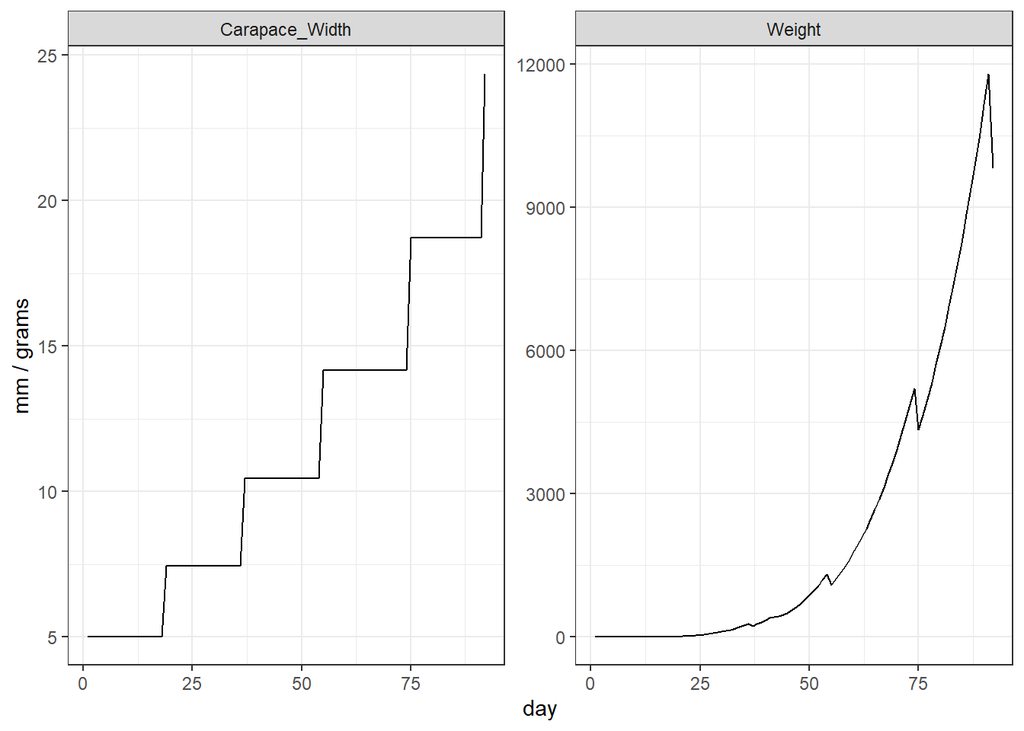

```r
plot.sim(sim.out =test.sim4,nd=nd)
```

compare simulated weight to weight based on carapace width:

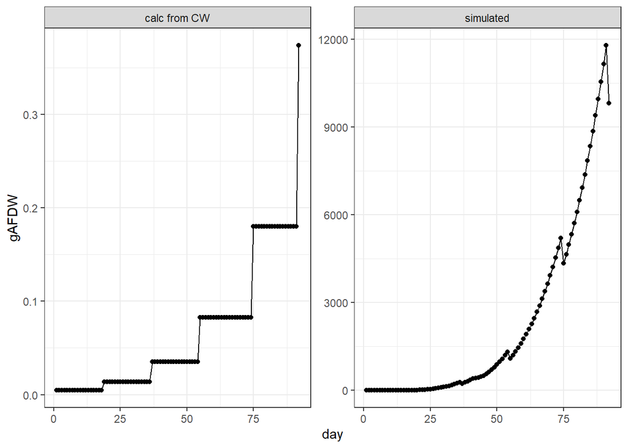

```r
data.frame(day=rep(1:(nd+1), 2),
           type=c(rep("simulated",nd+1),rep("calc from CW",nd+1)),
           gAFDW=c(test.sim4$W,sapply(test.sim4$CW,cw2afdw))) %>%
  ggplot(aes(x=day,y=gAFDW)) +
  geom_point() + geom_path() +
  facet_wrap(~type, scales="free_y") + labs("RFR=0.75; pIloss=0.10; pIndigest=0.40")
```

Nothing seems to be changing for proportion of indigestible prey > 0? But regardless, g AFDW for the simulation is too large.

## bioE

Plot growth / consumption / respiration across temperature range

```r
tmp.g <- data.frame(bioE(par=parms,
                                  data=dcrab_data)[[2]]) %>%
  dplyr::select(TempC,G_ggd,G_som_ggd,G_lipid_ggd,G_shell_ggd,
                Cmax_ggd,C_ggd,
                R_ggd,R_Act_ggd)

tmp.g.long <- tmp.g %>% pivot_longer(cols=c(2:ncol(tmp.g)), names_to="variable", values_to="ggd")
```

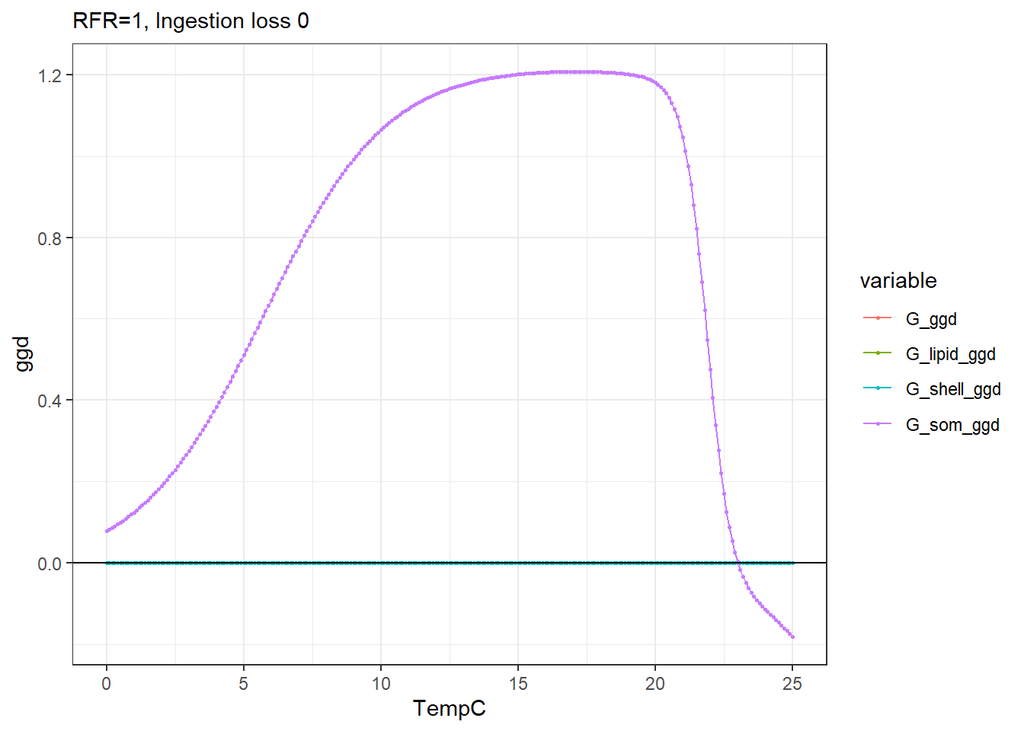

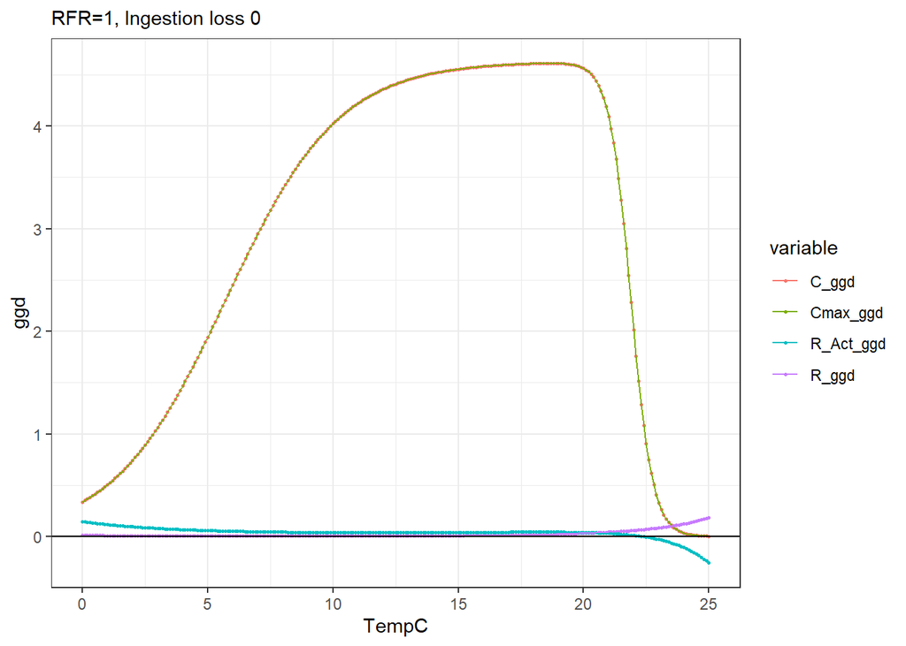

As in the last simulation, reduce RFR to 0.4, make Ingestion loss 10%

```r
sim_dat <- dcrab_data
sim_dat$propDiet <- 1
sim_dat$propIloss <- 0.10

parms2 <- parms
parms2$RFR <- 0.40


## rerun bioE
tmp.g2 <- data.frame(bioE(par=parms2,
                                  data=sim_dat)[[2]]) %>%
  dplyr::select(TempC,G_ggd,G_som_ggd,G_lipid_ggd,G_shell_ggd,
                Cmax_ggd,C_ggd,
                R_ggd,R_Act_ggd)

tmp.g2.long <- tmp.g2 %>% pivot_longer(cols=c(2:ncol(tmp.g2)), names_to="variable", values_to="ggd")
```

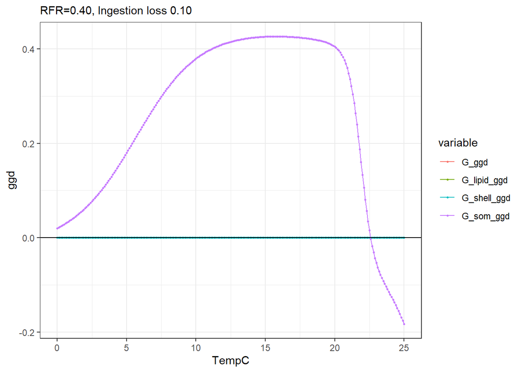

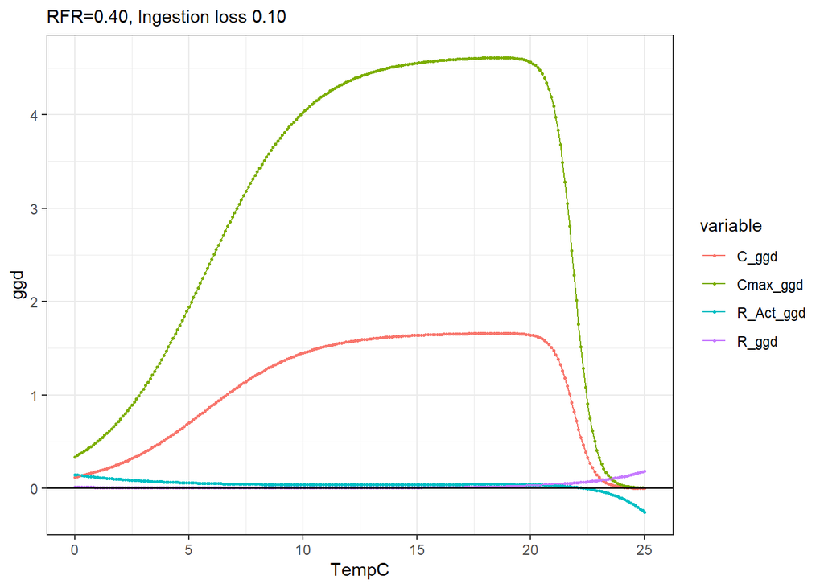

Consumption is waaaay higher than respiration.

There is a note where I was supposed to make sure the Act intercept parameter in the respiration function (`11.336`) was in the correct units. It looks like I had to convert respiration from g AFDW / hr to g AFDW / day. Maybe I needed to also do this with the `Act` intercept? Test this by adjusting the `customresp` aregument in the crab dataframe.

```r
sim_dat <- dcrab_data

sim_dat$customresp <- function(par,data){
  lnR_ulO2_gAFDWhr  <- par$RA*(data$TempC^2) + (par$RB*data$TempC*log(data$W + 10^-9)) + (data$RC*data$TempC) + data$RD
  R_ulO2_gAFDWhr    <- exp(lnR_ulO2_gAFDWhr)
  R_ulO2_gAFDWhr *24  -> R_ulO2_gAFDWd
  R_ulO2_gAFDWd*0.001 -> R_mlO2_gAFDWd
  R_mlO2_gAFDWd*4.8   -> R_cal_gAFDWd
  R_cal_gAFDWd*4.186  -> R_jgAFDWd
  R_jgAFDWd/1000      -> R_kjgAFDWd
  Act <- (0.147*data$W) + (-0.533*data$TempC) + (11.336*24)
  # return(list(R_jgd=R_kjgAFDWd, Act=Act))
  return(list(R_jgd=R_jgAFDWd, Act=Act))
}


## rerun bioE
tmp.g3 <- data.frame(bioE(par=parms,
                                  data=sim_dat)[[2]]) %>%
  dplyr::select(TempC,G_ggd,G_som_ggd,G_lipid_ggd,G_shell_ggd,
                Cmax_ggd,C_ggd,
                R_ggd,R_Act_ggd)

tmp.g3.long <- tmp.g3 %>% pivot_longer(cols=c(2:ncol(tmp.g3)), names_to="variable", values_to="ggd")
```

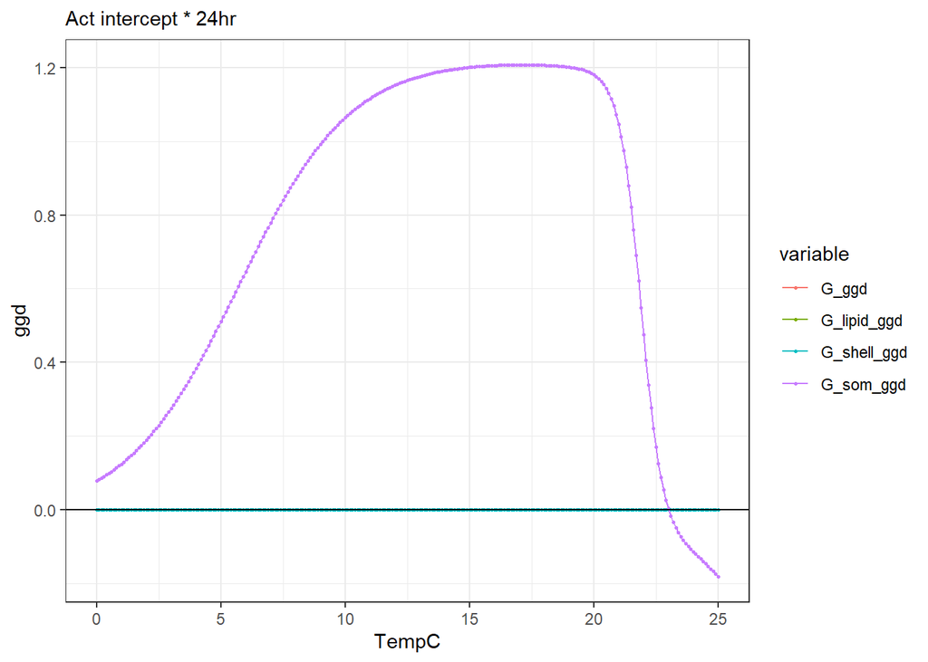

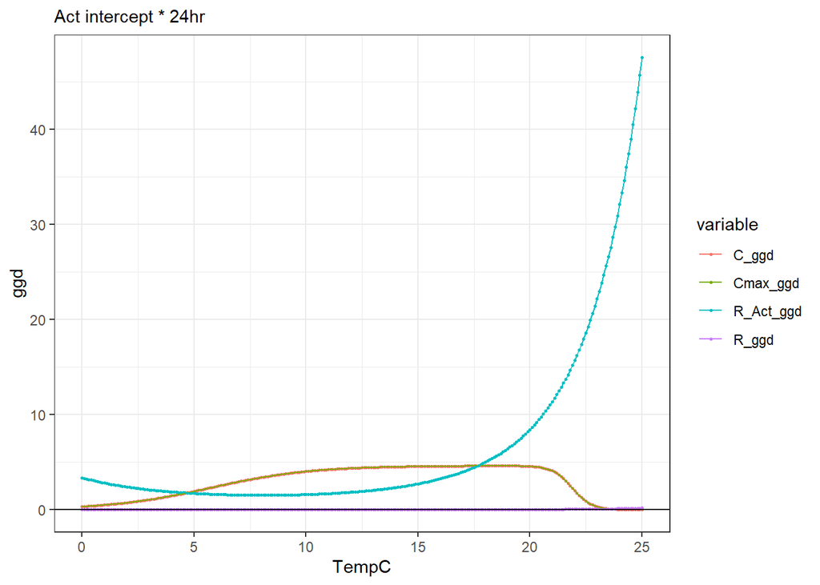

And when RFR / Prop I Loss are lower?

```r
sim_dat <- dcrab_data
sim_dat$propDiet <- 1
sim_dat$propIloss <- 0.10
sim_dat$propIndigest <- 0.40

# parms2 <- parms
# parms2$RFR <- 0.40

sim_dat$customresp <- function(par,data){
  lnR_ulO2_gAFDWhr  <- par$RA*(data$TempC^2) + (par$RB*data$TempC*log(data$W + 10^-9)) + (data$RC*data$TempC) + data$RD
  R_ulO2_gAFDWhr    <- exp(lnR_ulO2_gAFDWhr)
  R_ulO2_gAFDWhr *24  -> R_ulO2_gAFDWd
  R_ulO2_gAFDWd*0.001 -> R_mlO2_gAFDWd
  R_mlO2_gAFDWd*4.8   -> R_cal_gAFDWd
  R_cal_gAFDWd*4.186  -> R_jgAFDWd
  R_jgAFDWd/1000      -> R_kjgAFDWd
  Act <- (0.147*data$W) + (-0.533*data$TempC) + (11.336*24)
  # return(list(R_jgd=R_kjgAFDWd, Act=Act))
  return(list(R_jgd=R_jgAFDWd, Act=Act))
}

## rerun bioE
tmp.g4 <- data.frame(bioE(par=parms2,
                                  data=sim_dat)[[2]]) %>%
  dplyr::select(TempC,G_ggd,G_som_ggd,G_lipid_ggd,G_shell_ggd,
                Cmax_ggd,C_ggd,
                R_ggd,R_Act_ggd)

tmp.g4.long <- tmp.g4 %>% pivot_longer(cols=c(2:ncol(tmp.g4)), names_to="variable", values_to="ggd")
```

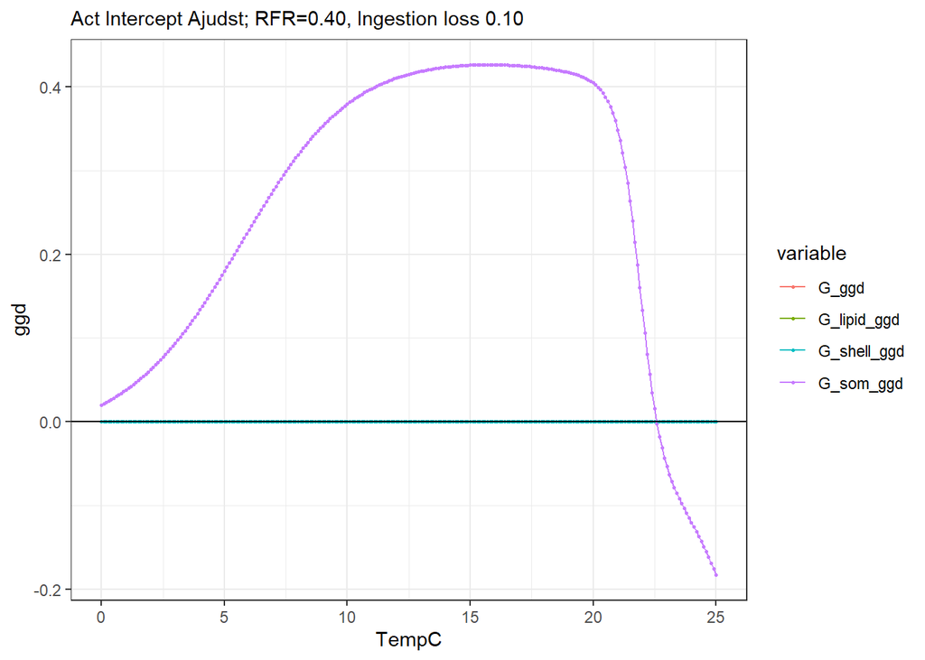

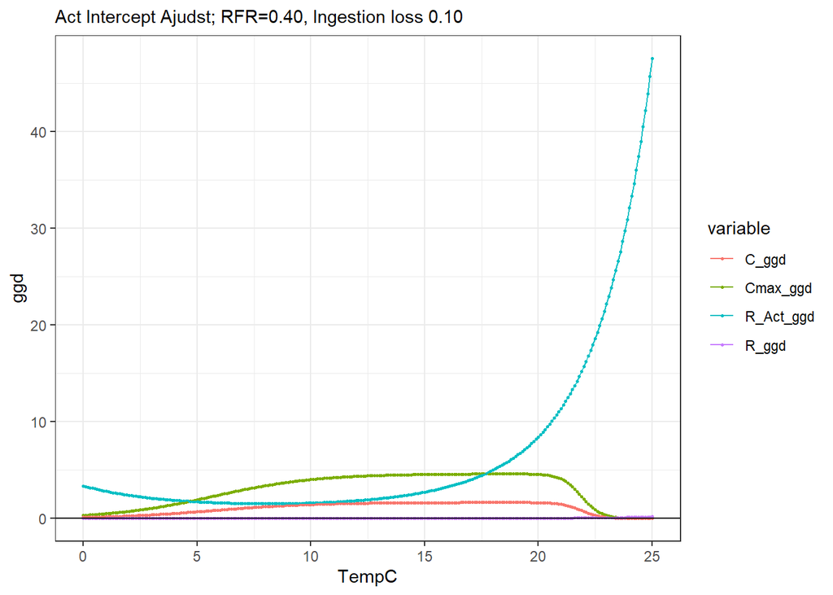

Check that this doesn’t make a difference in the simulation

```r
sim_dat <- dcrab_data
sim_dat$propDiet <- 1
sim_dat$propIloss <- 0.10
sim_dat$propIndigest <- 0.40

sim_dat$customresp <- function(par,data){
  lnR_ulO2_gAFDWhr  <- par$RA*(data$TempC^2) + (par$RB*data$TempC*log(data$W + 10^-9)) + (data$RC*data$TempC) + data$RD
  R_ulO2_gAFDWhr    <- exp(lnR_ulO2_gAFDWhr)
  R_ulO2_gAFDWhr *24  -> R_ulO2_gAFDWd
  R_ulO2_gAFDWd*0.001 -> R_mlO2_gAFDWd
  R_mlO2_gAFDWd*4.8   -> R_cal_gAFDWd
  R_cal_gAFDWd*4.186  -> R_jgAFDWd
  R_jgAFDWd/1000      -> R_kjgAFDWd
  Act <- (0.147*data$W) + (-0.533*data$TempC) + (11.336*24)
  # return(list(R_jgd=R_kjgAFDWd, Act=Act))
  return(list(R_jgd=R_jgAFDWd, Act=Act))
}
```

```r
## temperatures
sim_dat$TempC <- summerTdat$TempC     ## temperatures

## starting crab weight
sim_dat$W     <- W_start         ## set W data for the simulation to the first observed weight


##
nd     <-  dim(summerTdat)[1] # days of simulation

## weights at start and end of simulation
Wobs   <- data.frame(
  day = c(1,nd),
  W   = c(W_start,W_end))
Wobs$date <- summerTdat$date[Wobs$day]

# simulation data frames
DCRBdat4sim   <- list(
                  Wtarget  = Wobs,
                  parSIM  = parms,
                  simTdat = summerTdat,
                  dataSIM  = sim_dat,
                  dataMOLT = dataMOLT$Cmagister)

sim_out       <- summerTdat %>% mutate(W=0)
```

```r
test.sim4 <- sim_W(par=0.4, dataIN=DCRBdat4sim, LL=F)
```

```
## WARNING: crab weight is less than 8% of carapace width on day 2. (0.104%)
```

```
## WARNING: crab weight is less than 8% of carapace width on day 3. (0.201%)
```

```
## WARNING: crab weight is less than 8% of carapace width on day 4. (0.489%)
```

```
## WARNING: crab weight is less than 8% of carapace width on day 5. (1.131%)
```

```
## WARNING: crab weight is less than 8% of carapace width on day 6. (2.318%)
```

```
## WARNING: crab weight is less than 8% of carapace width on day 7. (4.36%)
```

```
## WARNING: crab weight is less than 8% of carapace width on day 8. (7.663%)
```

```
## daily growth includes energy lost to exuvia / spawning (3235.99 J/g predator)
```

```
## carapace width 88.56 calculated from weight; using the equation: 0.000164 * CW^2.79.
```

```
## daily growth includes energy lost to exuvia / spawning (3235.99 J/g predator)
```

```
## carapace width 263.18 calculated from weight; using the equation: 0.000164 * CW^2.79.
```

```
## daily growth includes energy lost to exuvia / spawning (3235.99 J/g predator)
```

```
## carapace width 454.68 calculated from weight; using the equation: 0.000164 * CW^2.79.
```

```
## daily growth includes energy lost to exuvia / spawning (3235.99 J/g predator)
```

```
## carapace width 744.39 calculated from weight; using the equation: 0.000164 * CW^2.79.
```

```
## daily growth includes energy lost to exuvia / spawning (3235.99 J/g predator)
```

```
## carapace width 997.28 calculated from weight; using the equation: 0.000164 * CW^2.79.
```

```
## Your crab molted on day: 18, 36, 54, 74, 91,
```

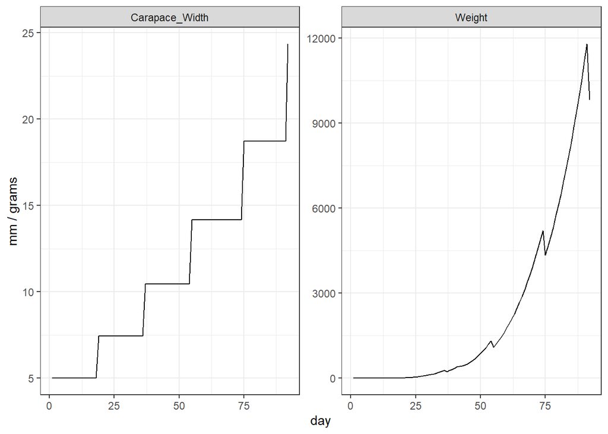

```r
plot.sim(sim.out =test.sim4,nd=nd)
```